# Outside Item Recollection

> This notebook focuses on recollection for items outside the rooms. The hit rate data was corrected by subtracting false alarm rate from the original hit rate. In those cases when the corrected hit rate was negative (the hit rate was lower than the false alarm rate), the corrected hit rate was forced to be 0. Note that the corrected hit rate is meaningful only when it was calculated as a mean.

# 1 Overview of the data

The rooms were separated into *Familiar* and *Novel* groups. Participants explored the *Familiar* group at the beginning of the experiment. In the encoding task, they visisted both *Familiar* and *Novel* groups. Their item memory (i.e., in which room they saw the item) was tested in the memory test the next day of the encoding task. **Novelty benefits** on the item memory are examined by comparing the memory performance between the *Familiar* and *Novel* groups.

Participants were also asked to rate how curious they felt about the room. The higher the rating is means they felt more curious about the room. Item memory as a function of curiosity rating was also examined for **curiosity benefits**.

Questionnaires on personal traits regarding curiosity were also administered to participants before the encoding task (i.e., PC and EC). Scores on these questionnaires might be able to predict the item memory or its relationship with curiosity rating.

# 2 Visual inspection of the data

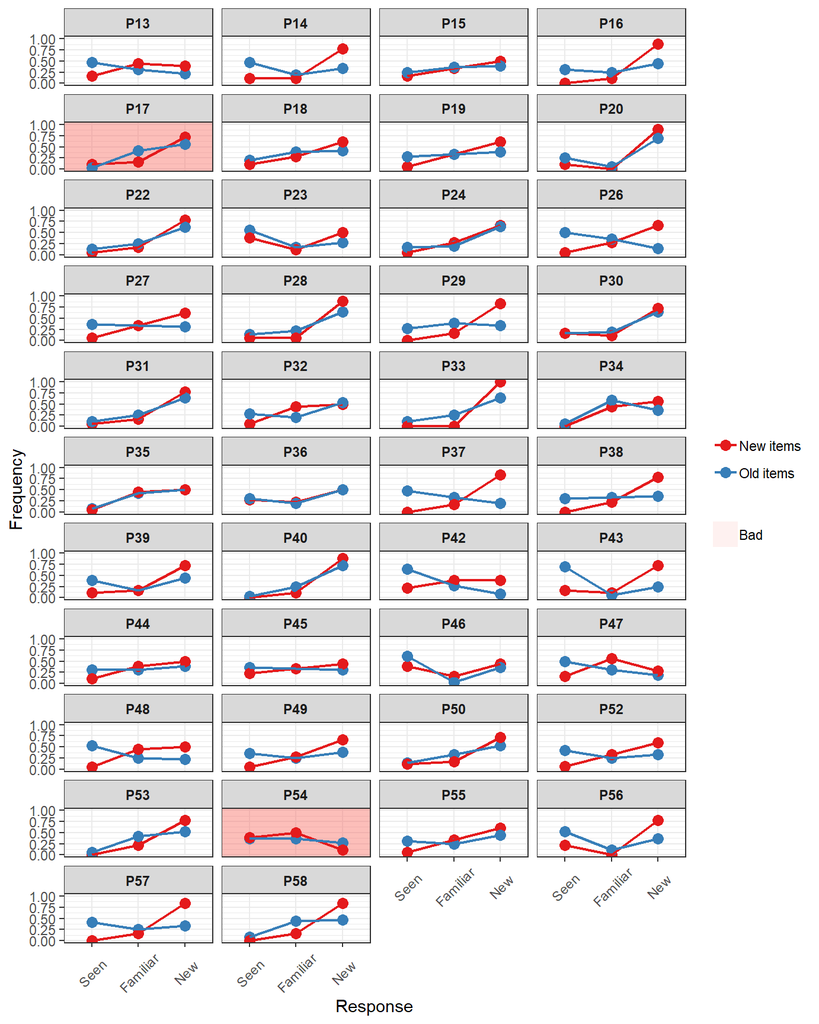

Figure 1. Response frequency for new and old items respectively for each individual participant.

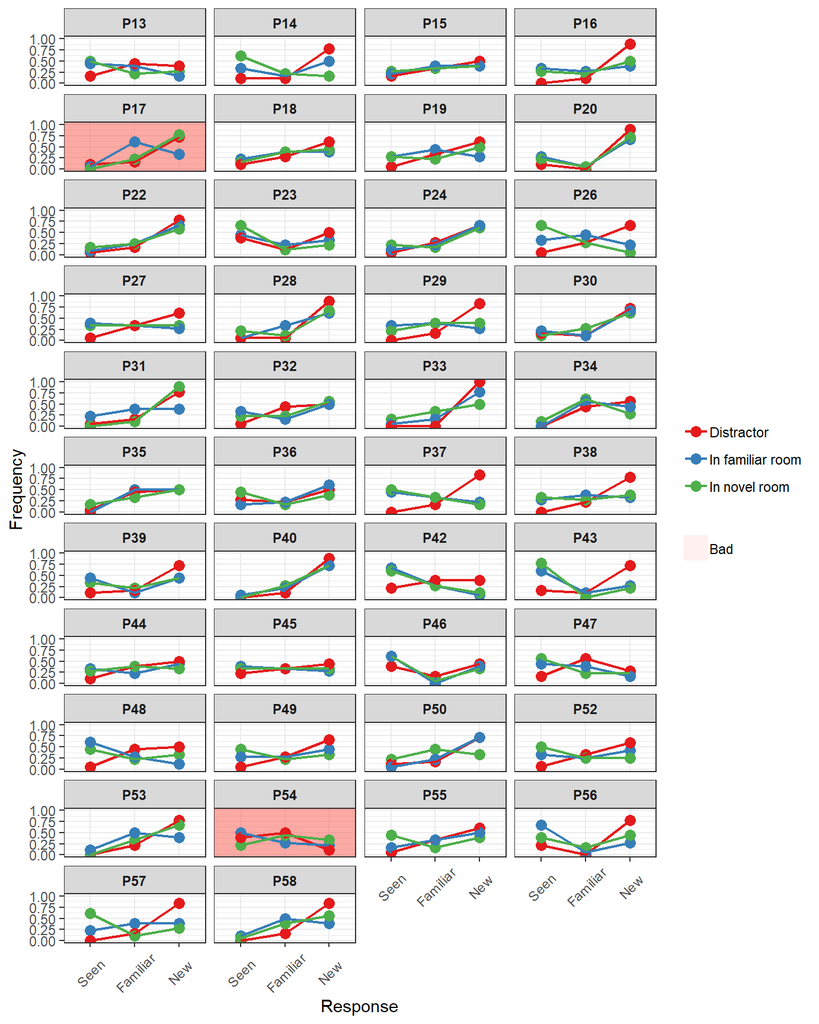

Figure 2. Response frequency for new and old items respectively for each Familiar/Novel group and each individual participant.

# 3 Novelty Benefits

We hypothesised that the memory for the items outside the rooms should be better for the *novel* rooms than for the *familiar* rooms.

## 3.1 Compare mean accuracy between *novel* and *familiar* rooms

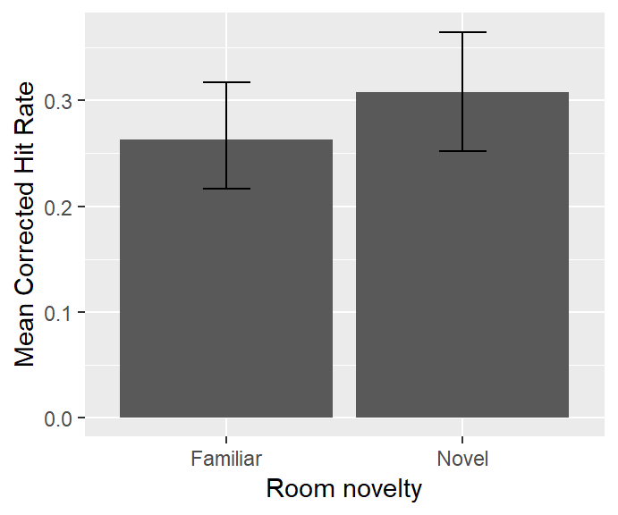

Figure 3. Mean hit rate for recollect response respectively for Familiar and Novel rooms.

```
##
##  Paired t-test
##
## data:  MeanCorrSeenHit by Group
## t = -1.8461, df = 39, p-value = 0.07247
## alternative hypothesis: true difference in means is not equal to 0
## 95 percent confidence interval:
##  -0.092653873  0.004227947
## sample estimates:
## mean of the differences
##             -0.04421296
```

The mean corrected hit rate for items was higher for the *Novel* rooms than for the *Familiar* rooms; however, the difference was short of significance, *t*(39) = -1.85, *p* = 0.072.

## 3.2 Item memory as a function of item order

### 3.2.1 Visualise the data

#### 3.2.1.1 Nonlinear

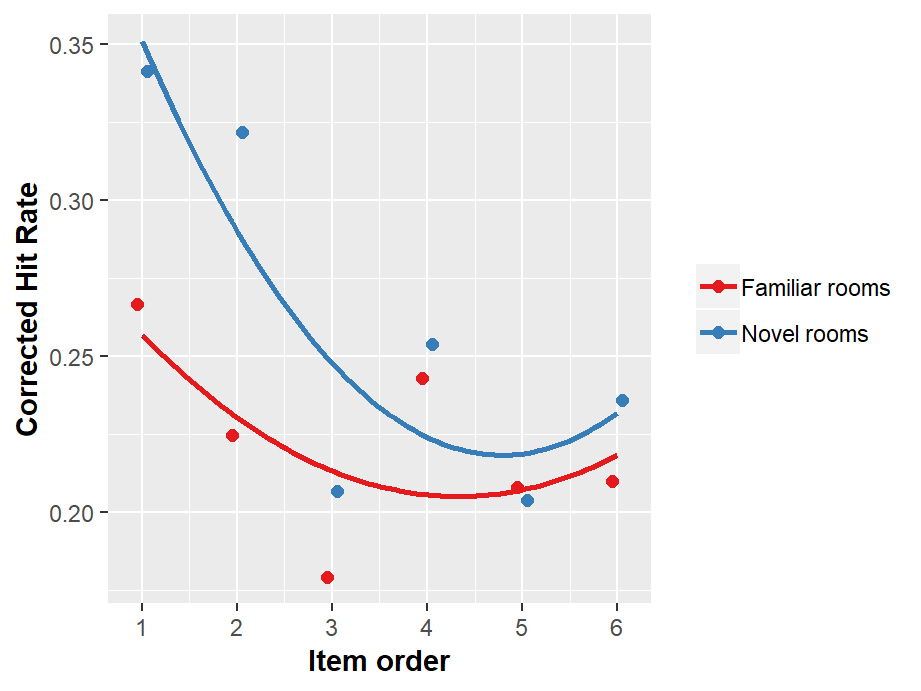

Figure 4. Mean hit rate for seen response at each order (i.e., 1st, 2nd, 3rd, etc), respectively for familiar and novel rooms.

#### 3.2.1.2 Linear

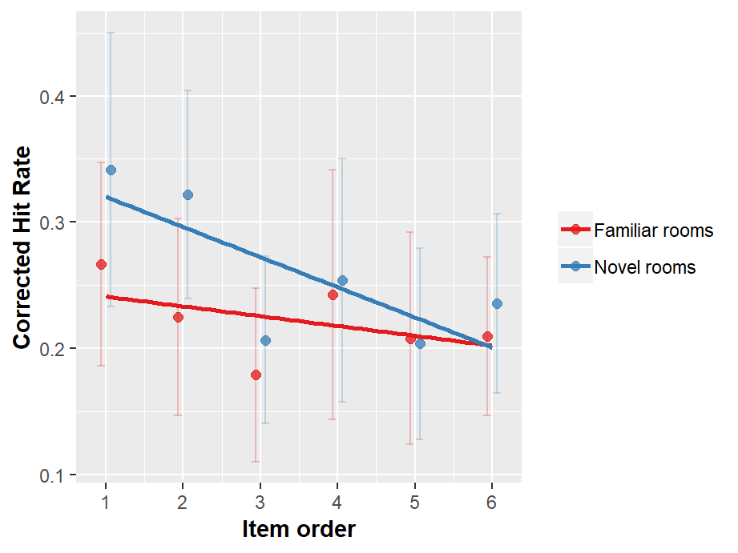

Figure 5. Mean hit rate for seen response at each order (i.e., 1st, 2nd, 3rd, etc), respectively for familiar and novel rooms.

From the figures above, we can see that the difference between the *Familiar* and *Novel* rooms decreased as the participant got closer to the room. The change was smaller for the *Familiar* rooms than the *Novel* room.

### 3.2.2 Testing novelty effects by fitting mixed models

Build models with item memory accuracy as $y$ and then examine effects of novelty by comparing the models.

- `baseline.item` is the model with only an intercept.
- `order.model.linear.1` is the model with $\small ItemOrder$ included, showing the effects of item order.
- `order.model.linear.2` is the model allowing the slope (i.e., relationship between item memory and item order) varying across participants.
- `order.model.quad.1` and `order.model.quad.2` repectively included $\small ItemOrder^2$ and related random effects.
- `novelty.model.1` is the model with $\small Group$ (i.e., *familiar* and *novel* rooms) included, examining the effects of novelty of the rooms on the intercept (i.e., mean item memory accuracy at the 1st order or overall if no difference in slope).
- `novelty.model.2` is the model with interaction between $\small Group$ and $\small ItemOrder$ included, examining the effects of novelty on how item memory accuracy changes as a function of item order.
- `novelty.model.3` included interaction between $\small Group$ and $\small ItemOrder^2$ for inestigating whether the pattern changes between *familiar* and *novel* groups.

```r
baseline.item <- lme(CorrSeenHit ~ 1, random = ~ 1|SubjectNo/Group, data = Curiosity.Recall.Old.Novelty[!SubjectNo %in% bad.ps.less.strict], method = "ML", control = list(msMaxIter = 500, opt = "optim", msVerbose=FALSE), na.action = na.exclude)

order.model.linear.1 <- update(baseline.item, .~. + ItemOrderCt)
# order.model.linear.2 <- update(order.model.linear.1, random = ~ 1 + ItemOrderCt|SubjectNo/Group)

# order.model.quad.1   <- update(order.model.linear.1, .~. + I(ItemOrderCt^2))
# order.model.quad.2   <- update(order.model.quad.1, random = ~ 1 + ItemOrderCt + I(ItemOrderCt^2)|SubjectNo/Group)

novelty.model.1 <- update(order.model.linear.1, .~. + Group)
novelty.model.2 <- update(novelty.model.1, .~. + Group:ItemOrderCt)
# novelty.model.3 <- update(novelty.model.2, .~. + Group:I(ItemOrderCt^2))

anova(baseline.item, order.model.linear.1, novelty.model.1, novelty.model.2)
```

```
##                      Model df       AIC      BIC     logLik   Test
## baseline.item            1  4 14.170384 30.86553 -3.0851920
## order.model.linear.1     2  5  9.374191 30.24312  0.3129046 1 vs 2
## novelty.model.1          3  6  8.364118 33.40683  1.8179411 2 vs 3
## novelty.model.2          4  7  8.579955 37.79646  2.7100224 3 vs 4
##                       L.Ratio p-value
## baseline.item
## order.model.linear.1 6.796193  0.0091
## novelty.model.1      3.010073  0.0827
## novelty.model.2      1.784163  0.1816
```

There was a significant main effect for item order, indicating that recollection of the items encountered at the beginning of the pathway was better than those encountered later.

As what we found on the mean hit rates above, the difference between the *Familiar* and *Novel* rooms was only marginally significant (*p* = 0.083).

However, we didn’t have a significant interaction between room novelty and item order (*p* = 0.18), so the difference in the change rate of recollection did not seem to differ significantly between *Familiar* and *Novel* rooms.

#### 3.2.2.1 Parameter estimation for the complete model

```
## Linear mixed-effects model fit by maximum likelihood
##  Data: Curiosity.Recall.Old.Novelty[!SubjectNo %in% bad.ps.less.strict]
##        AIC      BIC   logLik
##   8.579955 37.79646 2.710022
##
## Random effects:
##  Formula: ~1 | SubjectNo
##         (Intercept)
## StdDev:   0.1150596
##
##  Formula: ~1 | Group %in% SubjectNo
##         (Intercept)  Residual
## StdDev:  0.03439631 0.2252524
##
## Fixed effects: CorrSeenHit ~ ItemOrderCt + Group + ItemOrderCt:Group
##                         Value  Std.Error  DF   t-value p-value
## (Intercept)         0.3202249 0.03214955 398  9.960479  0.0000
## ItemOrderCt        -0.0238492 0.00854944 398 -2.789564  0.0055
## Group1             -0.0790079 0.03741242  39 -2.111810  0.0412
## ItemOrderCt:Group1  0.0161032 0.01209073 398  1.331861  0.1837
##  Correlation:
##                    (Intr) ItmOrC Group1
## ItemOrderCt        -0.665
## Group1             -0.582  0.571
## ItemOrderCt:Group1  0.470 -0.707 -0.808
##
## Standardized Within-Group Residuals:
##        Min         Q1        Med         Q3        Max
## -1.9575567 -0.6105261 -0.2087969  0.4752594  3.0418439
##
## Number of Observations: 480
## Number of Groups:
##            SubjectNo Group %in% SubjectNo
##                   40                   80
```

### 3.2.3 Collapse the order and novelty group

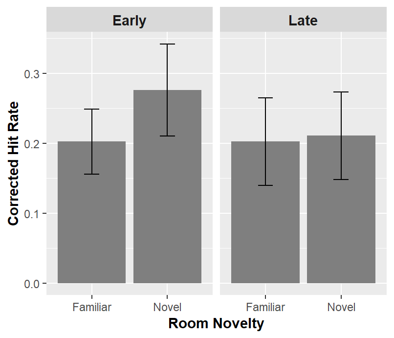

Figure 6. I collapsed the data into two order groups. The first three items encountered on the pathway were grouped into the Early group; and the last three items into the Late group.

#### 3.2.3.1 Stats on it

I used `lme` to calculate a repeated-measures ANOVA, as suggested by Andy Field’s *Discovering Statistics using R*.

```
##               Model df       AIC       BIC   logLik   Test  L.Ratio
## baseline          1  5 -104.0251 -88.64928 57.01258
## NoveltyModel      2  6 -105.2397 -86.78861 58.61983 1 vs 2 3.214502
## OrderModel        3  7 -105.4115 -83.88523 59.70573 2 vs 3 2.171794
## repeatedModel     4  8 -105.6439 -81.04246 60.82193 3 vs 4 2.232402
##               p-value
## baseline
## NoveltyModel   0.0730
## OrderModel     0.1406
## repeatedModel  0.1351
```

Comparing the models revealed a marginally significant main effect of *Novelty*, ${\chi}^2$(1) = 3.21, *p* = 0.073.

##### 3.2.3.1.1 Parameters in the complete model

```
## Linear mixed-effects model fit by maximum likelihood
##  Data: Curiosity.Recall.Old.Order.Novelty[!SubjectNo %in% bad.ps.less.strict]
##         AIC       BIC   logLik
##   -105.6439 -81.04246 60.82193
##
## Random effects:
##  Formula: ~1 | SubjectNo
##         (Intercept)
## StdDev:   0.1213897
##
##  Formula: ~1 | Group %in% SubjectNo
##         (Intercept)
## StdDev:  0.02488406
##
##  Formula: ~1 | ItemOrderType %in% Group %in% SubjectNo
##         (Intercept)   Residual
## StdDev:   0.1323785 0.03603822
##
## Fixed effects: CorrSeenHit ~ Group + ItemOrderType + Group:ItemOrderType
##                                Value  Std.Error DF   t-value p-value
## (Intercept)               0.27611111 0.02960314 78  9.327089  0.0000
## Group1                   -0.07361111 0.03157574 39 -2.331255  0.0250
## ItemOrderTypeLate        -0.06527778 0.03106884 78 -2.101069  0.0389
## Group1:ItemOrderTypeLate  0.06527778 0.04393797 78  1.485680  0.1414
##  Correlation:
##                          (Intr) Group1 ItmOTL
## Group1                   -0.533
## ItemOrderTypeLate        -0.525  0.492
## Group1:ItemOrderTypeLate  0.371 -0.696 -0.707
##
## Standardized Within-Group Residuals:
##         Min          Q1         Med          Q3         Max
## -0.47458491 -0.17660369 -0.03995522  0.15700966  0.63884529
##
## Number of Observations: 160
## Number of Groups:
##                               SubjectNo
##                                      40
##                    Group %in% SubjectNo
##                                      80
## ItemOrderType %in% Group %in% SubjectNo
##                                     160
```

##### 3.2.3.1.2 Simple effects for the “early” group

```
##
##  Paired t-test
##
## data:  CorrSeenHit by Group
## t = -2.4759, df = 39, p-value = 0.01774
## alternative hypothesis: true difference in means is not equal to 0
## 95 percent confidence interval:
##  -0.13374775 -0.01347447
## sample estimates:
## mean of the differences
##             -0.07361111
```

In consistent with the `lme` modelling above, comparing the mean corrected hit rate of the *Early* groups between the *Familiar* and *Novel* rooms revealed a significant difference, *t*(39) = -2.48, *p* = 0.018.

##### 3.2.3.1.3 Simple effects for the “late” group

```
##
##  Paired t-test
##
## data:  CorrSeenHit by Group
## t = -0.28273, df = 39, p-value = 0.7789
## alternative hypothesis: true difference in means is not equal to 0
## 95 percent confidence interval:
##  -0.06795120  0.05128453
## sample estimates:
## mean of the differences
##            -0.008333333
```

No difference for the *Late* groups.

# 4 Curiosity Benefits

We hypothesed that the higher the curiosity rating was, the better the item memory should be.

## 4.1 Mean accuracy of item memory as a function of curiosity rating

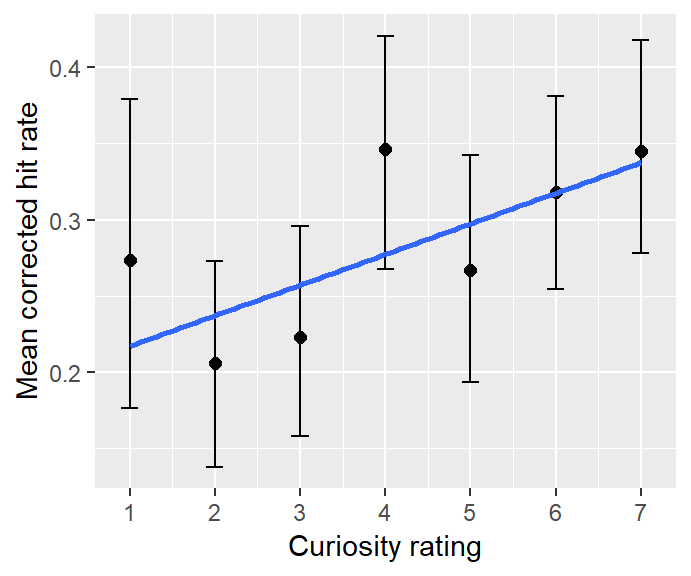

Figure 7. Mean hit rate as a function of curiosity rating.

### 4.1.1 Testing the relationship between mean accuracy of item memory and curiosity rating

Build models with item memory accuracy as $y$ and examine effects of curiosity rating by including it into the model and then comparing the model fits.

- `baseline.rating` is the model with only an intercept, showing no change in item memory as a function of curiosity rating.
- `rating.intercept` is the model with $\small CuriosityRating$ included, showing the effects of curiosity rating.
- `rating.slope` is the model allowing the slope (i.e., relationship between item memory and curiosity rating) varying across participants.

```
##                  Model df       AIC       BIC   logLik   Test  L.Ratio
## baseline.rating      1  3 -77.86584 -67.47434 41.93292
## rating.intercept     2  4 -81.97683 -68.12151 44.98842 1 vs 2 6.110996
## rating.slope         3  6 -82.48982 -61.70683 47.24491 2 vs 3 4.512984
##                  p-value
## baseline.rating
## rating.intercept  0.0134
## rating.slope      0.1047
```

There was a significant fixed effect of curiosity rating, ${\chi}^2(1)$ = 6.11, *p* = 0.013.

Allowing relationship between curiosity rating and recollection performance to vary across participants (*random effect*) improved the model fit, but not significantly, ${\chi}^2$(2) = 4.51, *p* = 0.10.

#### 4.1.1.1 Parameter estimates in the complete model

```r
summary(rating.slope)
```

```
## Linear mixed-effects model fit by maximum likelihood
##  Data: OutsideObjectsMemory[!SubjectNo %in% bad.ps.less.strict]
##         AIC       BIC   logLik
##   -82.48982 -61.70683 47.24491
##
## Random effects:
##  Formula: ~1 + CuriosityRating | SubjectNo
##  Structure: General positive-definite, Log-Cholesky parametrization
##                 StdDev     Corr
## (Intercept)     0.17748559 (Intr)
## CuriosityRating 0.03043525 -0.65
## Residual        0.16601016
##
## Fixed effects: CorrSeenHit ~ CuriosityRating
##                      Value  Std.Error  DF  t-value p-value
## (Intercept)     0.20826961 0.04109524 195 5.067974  0.0000
## CuriosityRating 0.01634939 0.00786035 195 2.079982  0.0388
##  Correlation:
##                 (Intr)
## CuriosityRating -0.806
##
## Standardized Within-Group Residuals:
##        Min         Q1        Med         Q3        Max
## -2.0741458 -0.6138912 -0.1081578  0.5504126  2.5474591
##
## Number of Observations: 236
## Number of Groups: 40
```

The slope was significantly larger than 0, *b* = 0.016, *t*(195) = 2.08, *p* = 0.039, indicating a positive relationship between curiosity rating and recollection performance (see the figure below).

#### 4.1.1.2 Plot the model

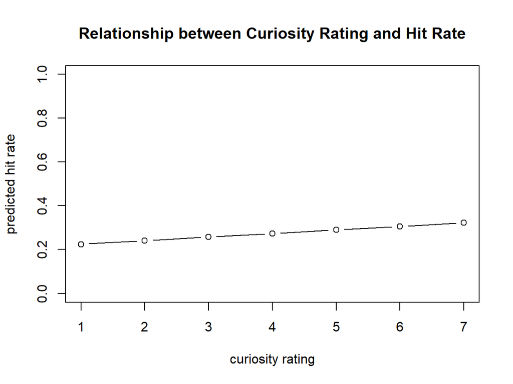

## 4.2 Does the relationship with curiosity rating depend on item order?

### 4.2.1 Curiosity Rating

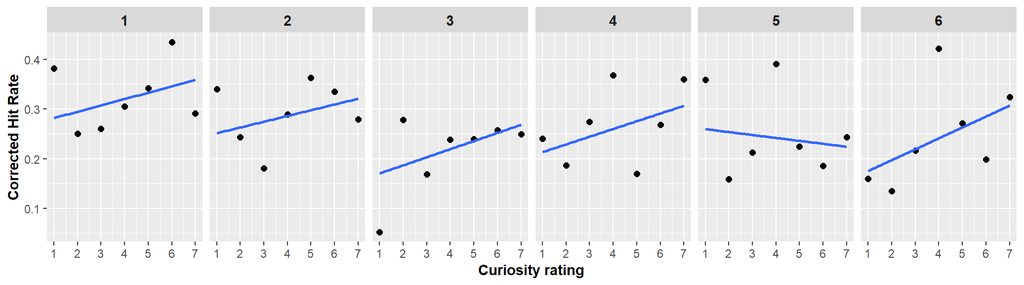

Figure 8. Mean hit rate across participants as a function of curiosity rating for each order at which the item was seen (I.e., 1st, 2nd, 3rd, etc.).

### 4.2.2 Normalised Curiosity Rating

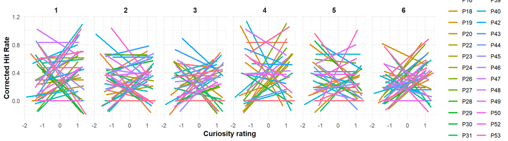

Figure 9. Mean hit rate across participants as a function of normalised curiosity rating for each order at which the item was seen (I.e., 1st, 2nd, 3rd, etc.).

### 4.2.3 Testing the effect of item order

Build models with context memory accuracy as $y$ and examine effects of curiosity rating and item order by comparing the models.

- `item.model.linear.1` is the model with $\small ItemOrder$ included (in addition to $\small CuriosityRating$), showing the effects of item order.
- `item.model.linear.2` is the model allowing the slope (i.e., relationship between item memory and item order) varying across participants.
- `item.model.linear.3` is the model with the interaction between $\small ItemOrders$ and $\small CuriosityRating$ included.
- `item.model.quad.1` and `item.model.quad.2` repectively included $\small ItemOrder^2$ and related random effects.
- `item.model.quad.3` included interaction between $\small ItemOrder^2$ and $\small CuriosityRating$ for inestigating whether the pattern changes as a function of *curiosity rating*.

#### 4.2.3.1 Original curiosity ratings

```r
baseline.item <- lme(CorrSeenHit ~ 1, random = ~ 1|SubjectNo, data = Curiosity.Recall.Old.CuriosityRating[!SubjectNo %in% bad.ps.less.strict], method = "ML", control = list(msMaxIter = 500, opt = "optim", msVerbose=FALSE), na.action = na.exclude)

rating.intercept <- update(baseline.item, .~. + CuriosityRating)
# rating.slope     <- update(rating.intercept, random = ~ 1 + CuriosityRating | SubjectNo)

item.model.linear.1     <- update(rating.intercept, .~. + ItemOrder)
# item.model.linear.2     <- update(item.model.linear.1, random = ~1+CuriosityRating + ItemOrder|SubjectNo)
item.model.linear.3     <- update(item.model.linear.1, .~. + ItemOrder : CuriosityRating)

# item.model.quad.1       <- update(item.model.linear.3, .~. + I(ItemOrder^2))
# item.model.quad.2       <- update(item.model.quad.1,   random = ~1+CuriosityRating+ItemOrder+I(ItemOrder^2)|SubjectNo) # excluding this model because singularity issue (perhaps the model was getting too complex to be calculated)
# item.model.quad.3       <- update(item.model.quad.2,   .~. + I(ItemOrder^2) : CuriosityRating)

anova(baseline.item, rating.intercept, item.model.linear.1, item.model.linear.3) #, item.model.quad.1, item.model.quad.2, item.model.quad.3)
```

```
##                     Model df      AIC      BIC    logLik   Test  L.Ratio
## baseline.item           1  3 1022.543 1037.675 -508.2715
## rating.intercept        2  4 1021.091 1041.267 -506.5454 1 vs 2 3.452078
## item.model.linear.1     3  5 1018.218 1043.438 -504.1090 2 vs 3 4.872922
## item.model.linear.3     4  6 1020.214 1050.478 -504.1068 3 vs 4 0.004354
##                     p-value
## baseline.item
## rating.intercept     0.0632
## item.model.linear.1  0.0273
## item.model.linear.3  0.9474
```

There was a marginally significant main effect of curiosity rating, ${\chi}^2$(1) = 3.45, *p* = 0.063, and significant main effect of item order, ${\chi}^2(1)$ = 4.87, *p* = 0.027. No significantly interaction was found between curiosity rating and item order, *p* = 0.95.

##### 4.2.3.1.1 Parameter estimation for the optimal model

```r
summary(item.model.linear.1 )
```

```
## Linear mixed-effects model fit by maximum likelihood
##  Data: Curiosity.Recall.Old.CuriosityRating[!SubjectNo %in% bad.ps.less.strict]
##        AIC      BIC   logLik
##   1018.218 1043.438 -504.109
##
## Random effects:
##  Formula: ~1 | SubjectNo
##         (Intercept)  Residual
## StdDev:   0.1208242 0.3665828
##
## Fixed effects: CorrSeenHit ~ CuriosityRating + ItemOrder
##                       Value  Std.Error   DF   t-value p-value
## (Intercept)      0.26759797 0.04051993 1104  6.604108  0.0000
## CuriosityRating  0.01101353 0.00591859 1104  1.860838  0.0630
## ItemOrder       -0.01401230 0.00634900 1104 -2.207008  0.0275
##  Correlation:
##                 (Intr) CrstyR
## CuriosityRating -0.634
## ItemOrder       -0.548  0.000
##
## Standardized Within-Group Residuals:
##        Min         Q1        Med         Q3        Max
## -1.4158853 -0.7257131 -0.3877738  0.8232497  2.5924336
##
## Number of Observations: 1146
## Number of Groups: 40
```

#### 4.2.3.2 **Normalised** curiosity ratings

Here **normalised** curiosity ratings was used, just to see if there would be any difference.

```r
baseline.item <- lme(CorrSeenHit ~ 1, random = ~ 1|SubjectNo, data = Curiosity.Recall.Old.CuriosityRatingN[!SubjectNo %in% bad.ps.less.strict], method = "ML", control = list(msMaxIter = 500, opt = "optim", msVerbose=FALSE), na.action = na.exclude)

rating.intercept <- update(baseline.item, .~. + NCuriosityRating)
# rating.slope     <- update(rating.intercept, random = ~ 1 + NCuriosityRating | SubjectNo)

item.model.linear.1     <- update(rating.intercept, .~. + ItemOrder)
# item.model.linear.2     <- update(item.model.linear.1, random = ~1+NCuriosityRating + ItemOrder|SubjectNo)
item.model.linear.3     <- update(item.model.linear.1, .~. + ItemOrder : NCuriosityRating)

# item.model.quad.1       <- update(item.model.linear.3, .~. + I(ItemOrder^2))
# item.model.quad.2       <- update(item.model.quad.1,   random = ~1+CuriosityRating+ItemOrder+I(ItemOrder^2)|SubjectNo) # excluding this model because singularity issue (perhaps the model was getting too complex to be calculated)
# item.model.quad.3       <- update(item.model.quad.2,   .~. + I(ItemOrder^2) : CuriosityRating)

anova(baseline.item, rating.intercept,item.model.linear.1, item.model.linear.3) #, item.model.quad.1, item.model.quad.2, item.model.quad.3)
```

```
##                     Model df      AIC      BIC    logLik   Test  L.Ratio
## baseline.item           1  3 1022.543 1037.675 -508.2715
## rating.intercept        2  4 1021.629 1041.805 -506.8144 1 vs 2 2.914112
## item.model.linear.1     3  5 1018.755 1043.975 -504.3774 2 vs 3 4.874058
## item.model.linear.3     4  6 1020.755 1051.019 -504.3774 3 vs 4 0.000000
##                     p-value
## baseline.item
## rating.intercept     0.0878
## item.model.linear.1  0.0273
## item.model.linear.3  1.0000
```

##### 4.2.3.2.1 Parameter estimation for the optimal model

```r
summary(item.model.linear.1 )
```

```
## Linear mixed-effects model fit by maximum likelihood
##  Data: Curiosity.Recall.Old.CuriosityRatingN[!SubjectNo %in% bad.ps.less.strict]
##        AIC      BIC    logLik
##   1018.755 1043.975 -504.3774
##
## Random effects:
##  Formula: ~1 | SubjectNo
##         (Intercept)  Residual
## StdDev:   0.1224343 0.3665399
##
## Fixed effects: CorrSeenHit ~ NCuriosityRating + ItemOrder
##                       Value   Std.Error   DF   t-value p-value
## (Intercept)       0.3164476 0.031483198 1104 10.051316  0.0000
## NCuriosityRating  0.0202140 0.011813185 1104  1.711142  0.0873
## ItemOrder        -0.0140123 0.006348261 1104 -2.207266  0.0275
##  Correlation:
##                  (Intr) NCrstR
## NCuriosityRating  0.019
## ItemOrder        -0.706  0.000
##
## Standardized Within-Group Residuals:
##        Min         Q1        Med         Q3        Max
## -1.4061355 -0.7246523 -0.3920024  0.8310758  2.5849574
##
## Number of Observations: 1146
## Number of Groups: 40
```

Results are similar to the models on the original curiosity ratings.

### 4.2.4 Collapse the order and curiosity rating

#### 4.2.4.1 Collapsing data into *Low* curiosity (ratings of 1 - 3) and *High* curiosity (ratings of 4 - 7) groups.

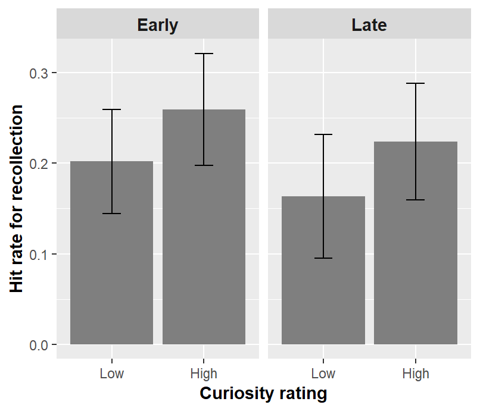

Figure 9. Mean hit rate as a function of item order (Early vs. Late) and curiosity (Low vs. High).

##### 4.2.4.1.1 Stats on it

Using `lme`

```
##                  Model df       AIC       BIC   logLik   Test  L.Ratio
## baseline             1  5 -76.75288 -61.63348 43.37644
## curiosityModel       2  6 -79.82958 -61.68630 45.91479 1 vs 2 5.076696
## orderModel           3  7 -80.03091 -58.86375 47.01546 2 vs 3 2.201331
## interactionModel     4  8 -78.03463 -53.84359 47.01732 3 vs 4 0.003724
##                  p-value
## baseline
## curiosityModel    0.0242
## orderModel        0.1379
## interactionModel  0.9513
```

There was a significant main effect of curiosity rating, ${\chi}^2$(1) = 5.08, *p* = 0.024.

No significant interaction.

```r
summary(interactionModel)
```

[output not shown]

##### 4.2.4.1.2 Linear trend respectivley for High and Low curiosity groups

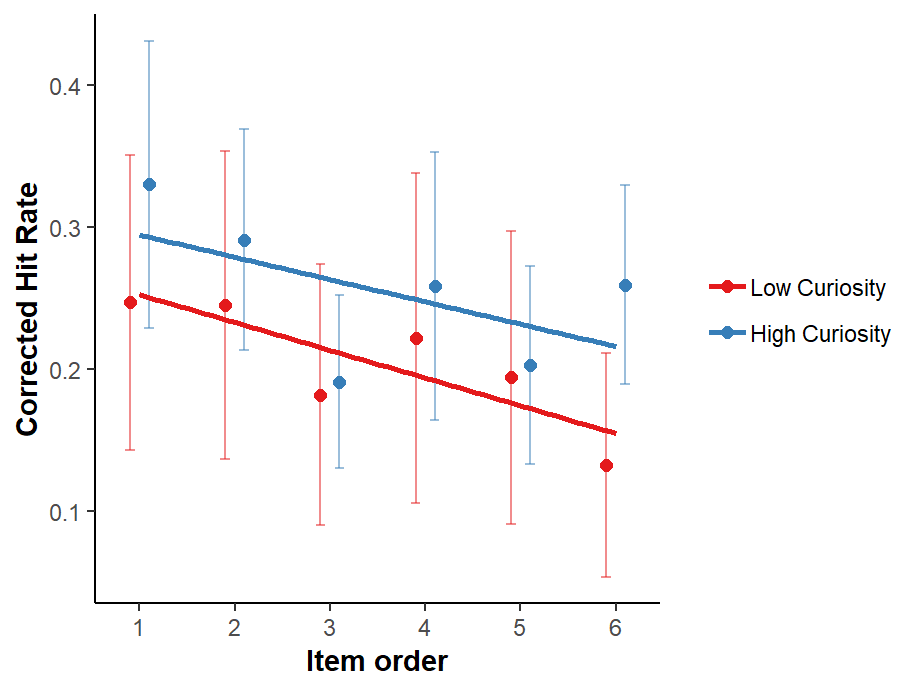

```r
baseline           <- lme(CorrSeenHit ~ 1, random = ~ 1|SubjectNo/CuriosityRatingType, data = Curiosity.Recall.Old.CuriosityType[!SubjectNo %in% bad.ps.less.strict], method = "ML", control = list(msMaxIter = 500, opt = "optim"))

orderModel.int     <- update(baseline,         .~. + ItemOrder)
orderModel.slp     <- update(orderModel.int,   random = ~ 1 + ItemOrder|SubjectNo/CuriosityRatingType )

curiosityModel     <- update(orderModel.slp,   .~. + CuriosityRatingType)
interactionModel   <- update(curiosityModel,   .~. + CuriosityRatingType : ItemOrder)

anova(baseline, orderModel.int, orderModel.slp, curiosityModel, interactionModel)
```

```
##                  Model df      AIC      BIC    logLik   Test  L.Ratio
## baseline             1  4 94.06844 110.5584 -43.03422
## orderModel.int       2  5 89.52262 110.1351 -39.76131 1 vs 2 6.545825
## orderModel.slp       3  9 95.05220 132.1546 -38.52610 2 vs 3 2.470412
## curiosityModel       4 10 92.86102 134.0859 -36.43051 3 vs 4 4.191180
## interactionModel     5 11 94.78899 140.1364 -36.39449 4 vs 5 0.072034
##                  p-value
## baseline
## orderModel.int    0.0105
## orderModel.slp    0.6499
## curiosityModel    0.0406
## interactionModel  0.7884
```

There was a main effect of curiosity, *p* = 0.041.

#### 4.2.4.2 Try another way to calculate “High” and “Low” curiosity groups

> “High” - higher than mean; “Low” - lower than mean

##### 4.2.4.2.1 First compare the difference between the two curiosity groups.

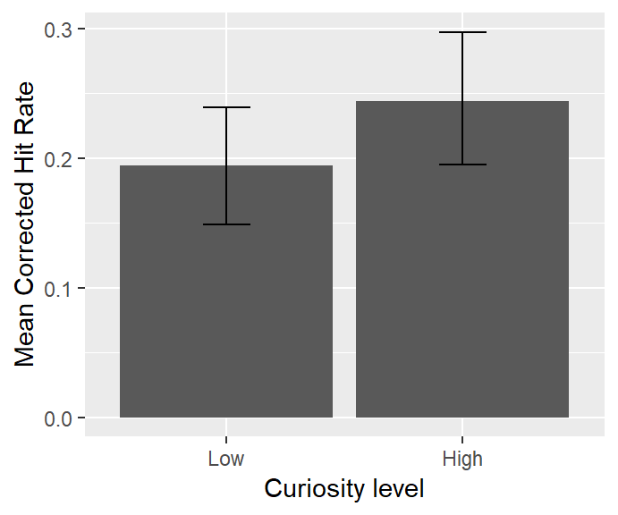

```
##
##  Paired t-test
##
## data:  CorrSeenHit by RatingGroup
## t = -2.0414, df = 39, p-value = 0.04802
## alternative hypothesis: true difference in means is not equal to 0
## 95 percent confidence interval:
##  -0.0995424207 -0.0004575793
## sample estimates:
## mean of the differences
##                   -0.05
```

Recollection was better for the *High curiosity* group than the *Low curiosity* group, *t*(39) = 2.04, *p* = 0.048.

##### 4.2.4.2.2 Relationship with item order

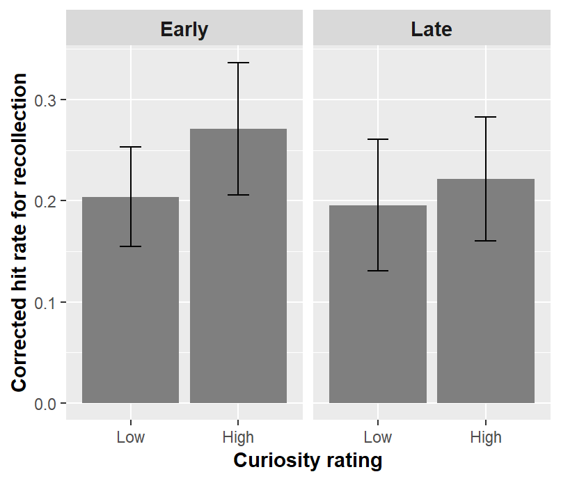

##### 4.2.4.2.3 Stats on it

```
##                  Model df        AIC       BIC   logLik   Test  L.Ratio
## baseline             1  5  -99.09696 -83.72109 54.54848
## ratingModel          2  6 -100.81142 -82.36038 56.40571 1 vs 2 3.714463
## orderModel           3  7 -100.49582 -78.96960 57.24791 2 vs 3 1.684395
## interactionModel     4  8  -99.36232 -74.76093 57.68116 3 vs 4 0.866505
##                  p-value
## baseline
## ratingModel       0.0539
## orderModel        0.1943
## interactionModel  0.3519
```

There was a marginally significant main effect of curiosity rating, ${\chi}^2$(1) = 3.71, *p* = 0.054.

No interaction.

#### 4.2.4.3 Linear trend respectivley for High and Low curiosity groups

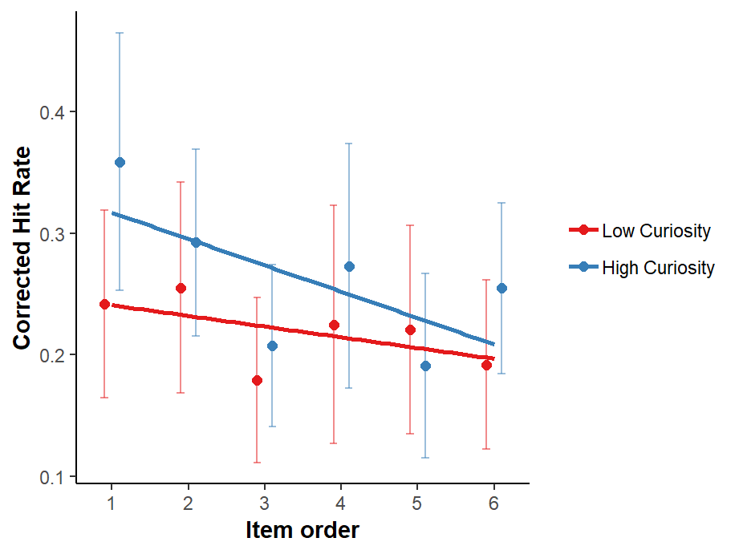

```r
Curiosity.Recall.Old.CuriosityType.MeanSep$ItemOrderCt <- Curiosity.Recall.Old.CuriosityType.MeanSep$ItemOrder - 1

baseline <- lme(CorrSeenHit ~ 1, random = ~ 1|SubjectNo/RatingGroup, data = Curiosity.Recall.Old.CuriosityType.MeanSep[!SubjectNo %in% bad.ps.less.strict], method = "ML", control = list(msMaxIter = 500, opt = "optim", msVerbose=FALSE), na.action = na.exclude)

orderModel.linear.1   <- update(baseline,              .~. + ItemOrderCt)
orderModel.linear.2   <- update(orderModel.linear.1,   random = ~ 1 + ItemOrderCt|SubjectNo/RatingGroup)

curiosityModel        <- update(orderModel.linear.2,   .~. + RatingGroup)
curiosityModel.linear <- update(curiosityModel,        .~. + RatingGroup : ItemOrderCt)

anova(baseline, orderModel.linear.1, orderModel.linear.2, curiosityModel, curiosityModel.linear)
```

```
##                       Model df      AIC      BIC     logLik   Test
## baseline                  1  4 28.81105 45.50619 -10.405523
## orderModel.linear.1       2  5 24.65576 45.52469  -7.327879 1 vs 2
## orderModel.linear.2       3  9 29.09249 66.65657  -5.546245 2 vs 3
## curiosityModel            4 10 27.24801 68.98587  -3.624003 3 vs 4
## curiosityModel.linear     5 11 28.19264 74.10429  -3.096320 4 vs 5
##                        L.Ratio p-value
## baseline
## orderModel.linear.1   6.155287  0.0131
## orderModel.linear.2   3.563268  0.4683
## curiosityModel        3.844485  0.0499
## curiosityModel.linear 1.055365  0.3043
```

Main effects of item order and curiosity, but no interaction.

# 5 Curiosity and novelty

TODO; will check better way of doing the analysis..

At the moment, I just ran the model building in two opposite orders, and to see how the degree of model fit improvement changed between two orders.

## 5.1 Testing the effects of curiosity rating and novelty together

Build models with item memory accuracy as $y$ and examine effects of curiosity rating and novelty together by including them into the model separately and then comparing the model fits.

- `baseline.rating` is the model with only an intercept, showing no change in item memory as a function of curiosity rating.
- `rating.intercept` is the model with $\small CuriosityRating$ included, showing the effects of curiosity rating.
- `rating.slope` is the model allowing the slope (i.e., relationship between item memory and curiosity rating) varying across participants.
- `novelty.model` is the model with $\small Group$ (i.e., *familiar* and *novel* rooms) included, examining the effects of novelty of the rooms on the intercept (i.e., mean item memory accuracy at the 1st order or overall if no difference in slope).
- `interaction.model` is the model with interaction between $\small Group$ and $\small CuriosityRating$ included, examining the effects of novelty on how item memory accuracy changes as a function of item order.

```
##                   Model df       AIC       BIC   logLik   Test  L.Ratio
## baseline.rating       1  4 -76.36648 -62.51115 42.18324
## rating.intercept      2  5 -80.15880 -62.83964 45.07940 1 vs 2 5.792323
## rating.slope          3  9 -76.48487 -45.31038 47.24243 2 vs 3 4.326066
## novelty.model.1       4 10 -74.49909 -39.86077 47.24954 3 vs 4 0.014218
## interaction.model     5 11 -73.11566 -35.01351 47.55783 4 vs 5 0.616573
##                   p-value
## baseline.rating
## rating.intercept   0.0161
## rating.slope       0.3637
## novelty.model.1    0.9051
## interaction.model  0.4323
```

Again, there was a significant main effect of curiosity rating, ${\chi}^2$(1) = 5.79, *p* = 0.016. No interaction.

## 5.2 What about the other way around

```
##                   Model df       AIC       BIC   logLik   Test  L.Ratio
## baseline.rating       1  4 -76.36648 -62.51115 42.18324
## novelty.model.1       2  5 -77.34047 -60.02131 43.67023 1 vs 2 2.973987
## rating.model.1        3  6 -78.20584 -57.42285 45.10292 2 vs 3 2.865373
## rating.model.2        4 10 -74.49909 -39.86077 47.24954 3 vs 4 4.293247
## interaction.model     5 11 -73.11566 -35.01351 47.55783 4 vs 5 0.616573
##                   p-value
## baseline.rating
## novelty.model.1    0.0846
## rating.model.1     0.0905
## rating.model.2     0.3678
## interaction.model  0.4323
```

## 5.3 Check the collapsed data

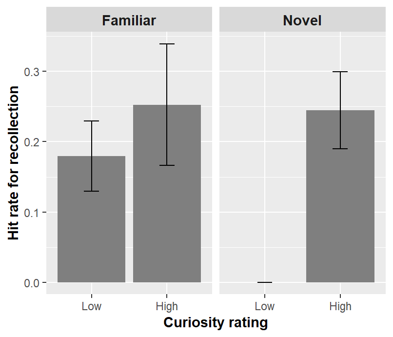

### 5.3.1 Alternative way to collapse data

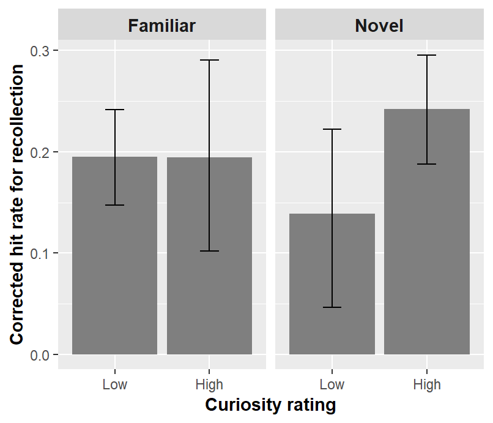

#### 5.3.1.1 Stats

Because there appeared to be different variance between groups, I used robust repeated measures ANOVA in `WRS2` package on the 20% trimmed means. However, this might not be a good approach as sample size might be quite small in some conditions. TODO; will check better way of doing the analysis..

```r
library(WRS2)

bwtrim(CorrSeenHit ~ RatingGroup * Group, id = SubjectNo, data = Curiosity.Recall.Old.Interaction.MeanSep[!SubjectNo %in% bad.ps.less.strict])
```

```
## Call:
## bwtrim(formula = CorrSeenHit ~ RatingGroup * Group, id = SubjectNo,
##     data = Curiosity.Recall.Old.Interaction.MeanSep[!SubjectNo %in%
##         bad.ps.less.strict])
##
##                    value df1     df2 p.value
## Group             0.0443   1 14.2778  0.8363
## RatingGroup       0.3532   1 15.6251  0.5608
## Group:RatingGroup 0.2225   1 15.6251  0.6437
```

# 6 Curiosity effects in the *Novel* group

## 6.1 Mean accuracy of item memory as a function of curiosity rating

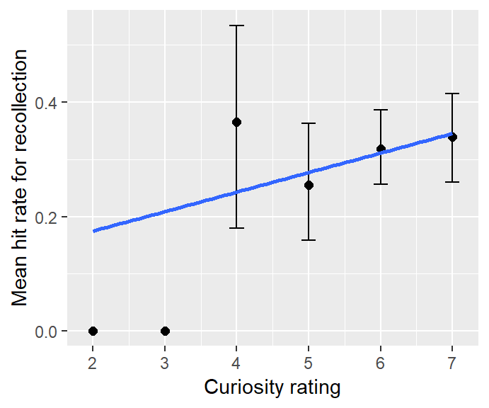